# Project title: Exploratory Data Analysis of Gapminder dataset

## Introduction

**The gapminder dataset is a built-in dataset in R that contains information about various countries over time, including their population, GDP per capita, life expectancy, and other factors. The goal of this project is to perform exploratory data analysis on this dataset to identify interesting patterns and trends.**

## Dataset

### The gapminder dataset contains data for 142 countries over the years 1952 to 2007. The following variables are included in the dataset:

**country:** Name of the country

**year:** Year of observation

**population:** Total population of the country

**continent:** Continent the country is located in

**lifeExp:** Life expectancy at birth in years

**gdpPercap:** Gross domestic product per capita in US dollars

## Tasks

**The following tasks will be performed as part of the project:**

Data wrangling: Clean and tidy the data, and convert it to a format suitable for analysis.

Univariate analysis: Examine the distribution and summary statistics of each variable individually, to identify outliers and missing values.

Bivariate analysis: Explore the relationship between pairs of variables, using scatter plots and correlation analysis.

Time series analysis: Analyze the trends and patterns in the data over time, using line plots and time series analysis techniques.

Statistical inference: Use hypothesis testing and confidence intervals to draw conclusions about the data and make predictions about future trends.

## Tools and technologies

**The following tools and technologies will be used in this project:**

R programming language

Tidyverse packages (dplyr, ggplot2, tidyr, etc.) for data wrangling and visualization

Time series analysis packages such as ts and forecast

## Deliverables

**The following deliverables will be produced as part of this project:**

A report summarizing the findings of the analysis, including visualizations and statistical analysis.

A presentation of the report, highlighting the key insights and recommendations.

Code used to perform the analysis, including data wrangling and visualization steps.

## Conclusion

**By performing exploratory data analysis on the gapminder dataset, we can gain insights into global trends and patterns over time. This project will provide an opportunity to use R programming skills to wrangle, analyze, and visualize data, and draw meaningful conclusions from it.**

```python
# Load the gapminder package
install.packages("gapminder")
library(gapminder)
```

```python
head(gapminder)
```

A tibble: 6 × 6

| country <fct> | continent <fct> | year <int> | lifeExp <dbl> | pop <int> | gdpPercap <dbl> |
| --- | --- | --- | --- | --- | --- |
| Afghanistan | Asia | 1952 | 28.801 | 8425333 | 779.4453 |
| Afghanistan | Asia | 1957 | 30.332 | 9240934 | 820.8530 |
| Afghanistan | Asia | 1962 | 31.997 | 10267083 | 853.1007 |
| Afghanistan | Asia | 1967 | 34.020 | 11537966 | 836.1971 |
| Afghanistan | Asia | 1972 | 36.088 | 13079460 | 739.9811 |
| Afghanistan | Asia | 1977 | 38.438 | 14880372 | 786.1134 |

```python
# Check the structure of the dataset
str(gapminder)
```

```
tibble [1,704 × 6] (S3: tbl_df/tbl/data.frame)
 $ country  : Factor w/ 142 levels "Afghanistan",..: 1 1 1 1 1 1 1 1 1 1 ...
 $ continent: Factor w/ 5 levels "Africa","Americas",..: 3 3 3 3 3 3 3 3 3 3 ...
 $ year     : int [1:1704] 1952 1957 1962 1967 1972 1977 1982 1987 1992 1997 ...
 $ lifeExp  : num [1:1704] 28.8 30.3 32 34 36.1 ...
 $ pop      : int [1:1704] 8425333 9240934 10267083 11537966 13079460 14880372 12881816 13867957 16317921 22227415 ...
 $ gdpPercap: num [1:1704] 779 821 853 836 740 ...
```

```python
# Check for missing values
sum(is.na(gapminder))
```

0

```python
# Examine summary statistics of each variable
summary(gapminder)
```

```
        country        continent        year         lifeExp
 Afghanistan:  12   Africa  :624   Min.   :1952   Min.   :23.60
 Albania    :  12   Americas:300   1st Qu.:1966   1st Qu.:48.20
 Algeria    :  12   Asia    :396   Median :1980   Median :60.71
 Angola     :  12   Europe  :360   Mean   :1980   Mean   :59.47
 Argentina  :  12   Oceania : 24   3rd Qu.:1993   3rd Qu.:70.85
 Australia  :  12                  Max.   :2007   Max.   :82.60
 (Other)    :1632
      pop              gdpPercap
 Min.   :6.001e+04   Min.   :   241.2
 1st Qu.:2.794e+06   1st Qu.:  1202.1
 Median :7.024e+06   Median :  3531.8
 Mean   :2.960e+07   Mean   :  7215.3
 3rd Qu.:1.959e+07   3rd Qu.:  9325.5
 Max.   :1.319e+09   Max.   :113523.1
```

```python
library(dplyr)
```

```python
#which countries is the highest in gdp per capita in 2007
the_highest_in_gdp<-
gapminder %>%
  filter(year == 2007) %>%
  select(country, gdpPercap) %>%
  arrange(-gdpPercap)

the_highest_in_gdp
```

A tibble: 142 × 2

| country <fct> | gdpPercap <dbl> |
| --- | --- |
| Norway | 49357.19 |
| Kuwait | 47306.99 |
| Singapore | 47143.18 |
| United States | 42951.65 |
| Ireland | 40676.00 |
| Hong Kong, China | 39724.98 |
| Switzerland | 37506.42 |
| Netherlands | 36797.93 |
| Canada | 36319.24 |
| Iceland | 36180.79 |
| Austria | 36126.49 |
| Denmark | 35278.42 |
| Australia | 34435.37 |
| Sweden | 33859.75 |
| Belgium | 33692.61 |
| Finland | 33207.08 |
| United Kingdom | 33203.26 |
| Germany | 32170.37 |
| Japan | 31656.07 |
| France | 30470.02 |
| Bahrain | 29796.05 |
| Spain | 28821.06 |
| Taiwan | 28718.28 |
| Italy | 28569.72 |
| Greece | 27538.41 |
| Slovenia | 25768.26 |
| Israel | 25523.28 |
| New Zealand | 25185.01 |
| Korea, Rep. | 23348.14 |
| Czech Republic | 22833.31 |
| ⋮ | ⋮ |
| Bangladesh | 1391.2538 |
| Ghana | 1327.6089 |
| Zambia | 1271.2116 |
| Burkina Faso | 1217.0330 |
| Haiti | 1201.6372 |
| Tanzania | 1107.4822 |
| Nepal | 1091.3598 |
| Uganda | 1056.3801 |
| Madagascar | 1044.7701 |
| Mali | 1042.5816 |
| Comoros | 986.1479 |
| Afghanistan | 974.5803 |
| Myanmar | 944.0000 |
| Guinea | 942.6542 |
| Somalia | 926.1411 |
| Togo | 882.9699 |
| Rwanda | 863.0885 |
| Sierra Leone | 862.5408 |
| Mozambique | 823.6856 |
| Malawi | 759.3499 |
| Gambia | 752.7497 |
| Central African Republic | 706.0165 |
| Ethiopia | 690.8056 |
| Eritrea | 641.3695 |
| Niger | 619.6769 |
| Guinea-Bissau | 579.2317 |
| Zimbabwe | 469.7093 |
| Burundi | 430.0707 |
| Liberia | 414.5073 |
| Congo, Dem. Rep. | 277.5519 |

```python
# Find median life expectancy and maximum GDP per capita in each continent in 1957
gapminder %>%
  filter(year == 1957) %>%
  group_by(continent) %>%
  summarize(medianLifeExp = median(lifeExp),
            maxGdpPercap = max(gdpPercap))
```

A tibble: 5 × 3

| continent <fct> | medianLifeExp <dbl> | maxGdpPercap <dbl> |
| --- | --- | --- |
| Africa | 40.5925 | 5487.104 |
| Americas | 56.0740 | 14847.127 |
| Asia | 48.2840 | 113523.133 |
| Europe | 67.6500 | 17909.490 |
| Oceania | 70.2950 | 12247.395 |

```python
# Find median life expectancy and maximum GDP per capita in each continent in 2007
gapminder %>%
  filter(year == 2007) %>%
  group_by(continent) %>%
  summarize(medianLifeExp = median(lifeExp),
            maxGdpPercap = max(gdpPercap))
```

A tibble: 5 × 3

| continent <fct> | medianLifeExp <dbl> | maxGdpPercap <dbl> |
| --- | --- | --- |
| Africa | 52.9265 | 13206.48 |
| Americas | 72.8990 | 42951.65 |
| Asia | 72.3960 | 47306.99 |
| Europe | 78.6085 | 49357.19 |
| Oceania | 80.7195 | 34435.37 |

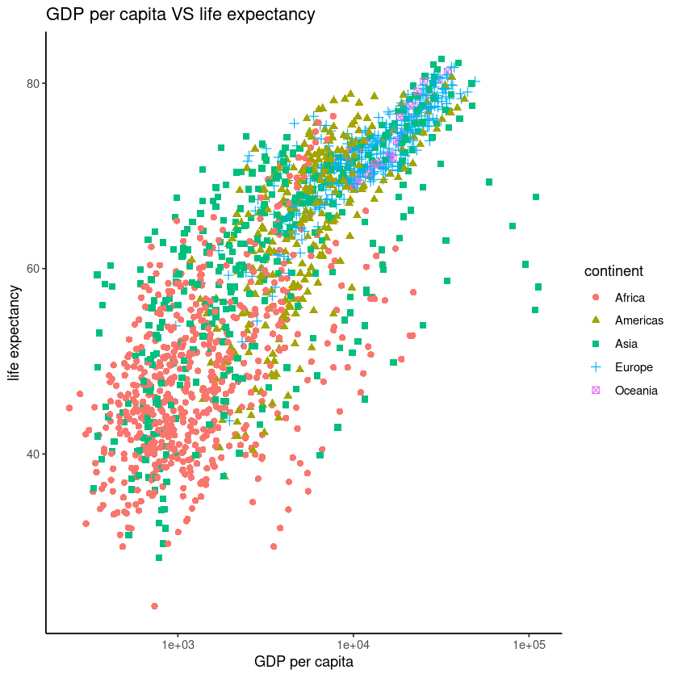

```python
# Create a scatter plot of GDP per capita vs. life expectancy
#import ggplot2
library(ggplot2)
gapminder%>%
ggplot( aes(x = gdpPercap, y = lifeExp,color=continent,shape=continent)) +
  geom_point(size = 2)+scale_x_log10()+theme_classic()+
  labs(title = "GDP per capita VS life expectancy",
       x = "GDP per capita",
       y = "life expectancy")
```

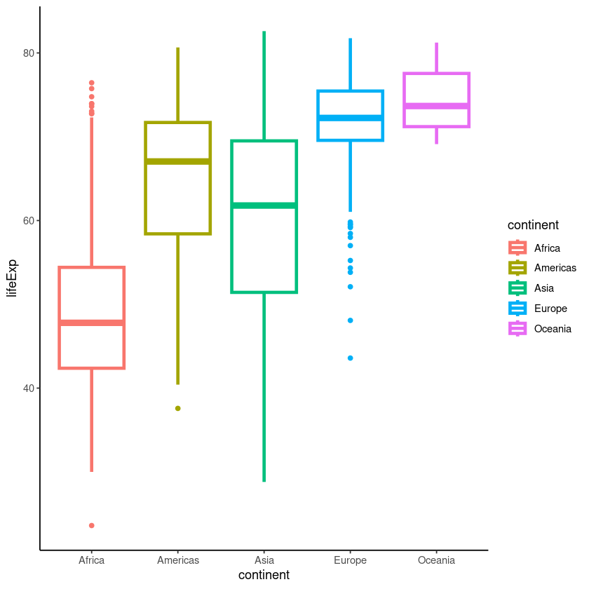

```python
# Create a box plot of life expectancy by continent
gapminder%>%
ggplot( aes(x = continent, y = lifeExp,color=continent)) +
  geom_boxplot( size = 1.3)+theme_classic()
```

```python
# Summarize the median gdpPercap by year & continent
by_year_continent<-gapminder%>%
group_by(year , continent)%>%
summarise(medianGdpPercap=median(gdpPercap))

by_year_continent
```

A grouped_df: 60 × 3

| year <int> | continent <fct> | medianGdpPercap <dbl> |
| --- | --- | --- |
| 1952 | Africa | 987.0256 |
| 1952 | Americas | 3048.3029 |
| 1952 | Asia | 1206.9479 |
| 1952 | Europe | 5142.4697 |
| 1952 | Oceania | 10298.0857 |
| 1957 | Africa | 1024.0230 |
| 1957 | Americas | 3780.5467 |
| 1957 | Asia | 1547.9448 |
| 1957 | Europe | 6066.7215 |
| 1957 | Oceania | 11598.5225 |
| 1962 | Africa | 1133.7837 |
| 1962 | Americas | 4086.1141 |
| 1962 | Asia | 1649.5522 |
| 1962 | Europe | 7515.7337 |
| 1962 | Oceania | 12696.4524 |
| 1967 | Africa | 1210.3764 |
| 1967 | Americas | 4643.3935 |
| 1967 | Asia | 2029.2281 |
| 1967 | Europe | 9366.0670 |
| 1967 | Oceania | 14495.0218 |
| 1972 | Africa | 1443.3725 |
| 1972 | Americas | 5305.4453 |
| 1972 | Asia | 2571.4230 |
| 1972 | Europe | 12326.3800 |
| 1972 | Oceania | 16417.3334 |
| 1977 | Africa | 1399.6388 |
| 1977 | Americas | 6281.2909 |
| 1977 | Asia | 3195.4846 |
| 1977 | Europe | 14225.7545 |
| 1977 | Oceania | 17283.9576 |
| 1982 | Africa | 1323.7283 |
| 1982 | Americas | 6434.5018 |
| 1982 | Asia | 4106.5253 |
| 1982 | Europe | 15322.8247 |
| 1982 | Oceania | 18554.7098 |
| 1987 | Africa | 1219.5856 |
| 1987 | Americas | 6360.9434 |
| 1987 | Asia | 4106.4923 |
| 1987 | Europe | 16215.4859 |
| 1987 | Oceania | 20448.0402 |
| 1992 | Africa | 1161.6314 |
| 1992 | Americas | 6618.7431 |
| 1992 | Asia | 3726.0635 |
| 1992 | Europe | 17550.1559 |
| 1992 | Oceania | 20894.0459 |
| 1997 | Africa | 1179.8831 |
| 1997 | Americas | 7113.6923 |
| 1997 | Asia | 3645.3796 |
| 1997 | Europe | 19596.4986 |
| 1997 | Oceania | 24024.1752 |
| 2002 | Africa | 1215.6832 |
| 2002 | Americas | 6994.7749 |
| 2002 | Asia | 4090.9253 |
| 2002 | Europe | 23674.8632 |
| 2002 | Oceania | 26938.7780 |
| 2007 | Africa | 1452.2671 |
| 2007 | Americas | 8948.1029 |
| 2007 | Asia | 4471.0619 |
| 2007 | Europe | 28054.0658 |
| 2007 | Oceania | 29810.1883 |

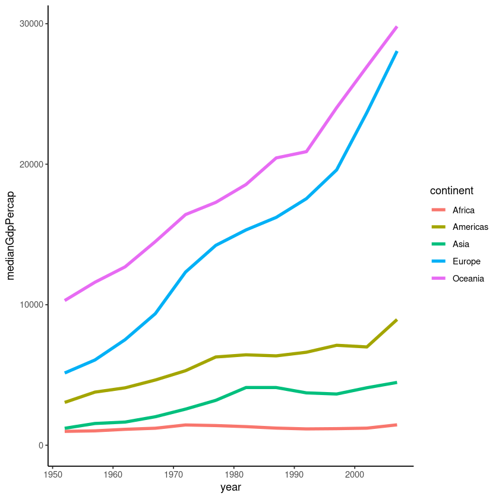

```python
# Create a line plot showing the change in medianGdpPercap by continent over time
by_year_continent%>%
ggplot(aes(x=year,y=medianGdpPercap,color=continent))+geom_line(size=1.5)+expand_limits(y = 0)+
theme_classic()
```

```python
# Observe the life expectancy in each different country in 2007 by creating histogram
gapminder_2007<-gapminder%>%
filter(year==2007)
```

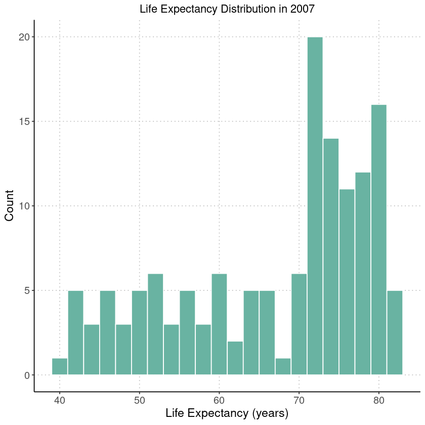

```python
ggplot(gapminder_2007, aes(x = lifeExp)) +
  geom_histogram(binwidth = 2, color = "white", fill = "#69b3a2") +
  labs(title = "Life Expectancy Distribution in 2007",
       x = "Life Expectancy (years)",
       y = "Count") +
  theme_classic() +
  theme(plot.title = element_text(hjust = 0.5),
        axis.text = element_text(size = 12),
        axis.title = element_text(size = 14),
        axis.line = element_line(color = "black"),
        panel.border = element_blank(),
        panel.grid.major = element_line(color = "grey", linetype = "dotted"))
```

### As you can see that most countries have a life expectancy between 70 to 80 years but have been another set of countries have life expectancies between 40 and 65

## Hypothes testing:

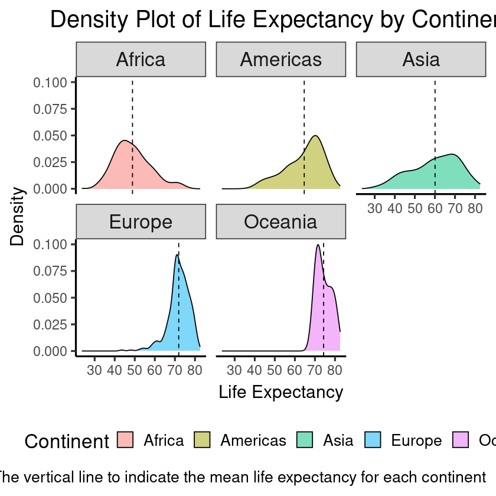

```python
# Define the mean life expectancy for each continent
df3 <- gapminder %>%
  group_by(continent) %>%
  summarize(meanlife = mean(lifeExp, na.rm = TRUE))

# Create a density plot of life expectancy by continent
#note we will add a vertical line to indicate the mean life expectancy for each continent
ggplot(data = gapminder, aes(x = lifeExp, fill = continent)) +
  geom_density(alpha = 0.5) +
  geom_vline(data = df3, aes(xintercept = meanlife), color = "black", linetype = "dashed") +
  labs(title = "Density Plot of Life Expectancy by Continent",
       x = "Life Expectancy", y = "Density") +
  scale_fill_discrete(name = "Continent") +
  facet_wrap(~ continent) +
  theme_bw(base_size = 20) +
  theme(plot.title = element_text(hjust =0.5 ),
        axis.title = element_text(size = 18),
        strip.text = element_text(size = 20),
        legend.position = "bottom",
        axis.text = element_text(size = 14),
        axis.line = element_line(color = "black"),
        panel.grid.major = element_blank(),
        panel.grid.minor = element_blank(),
        panel.border = element_blank(),
        panel.background = element_blank()) +
  scale_x_continuous(breaks = seq(0, 100, by = 10))+
  labs(caption = "The vertical line to indicate the mean life expectancy for each continent")
```

```python
# Single sample t-test
# Hypothes testing:
#the null Hypothes----> HO: the mean 1ife expectancy in Africa is 50 years
# vs                    Hl: the mean 1ife expectancy in Africa is not 50 years
```

```python
gapminder %>%
filter(continent == "Africa") %>%
select(lifeExp) %>%
t.test(mu = 50)#population mean it's equal to 50 in other words the assumed mean population mean is 50 and it's testing whether or not our sample data finds that is a statistically significant
```

```
	One Sample t-test

data:  .
t = -3.0976, df = 623, p-value = 0.002038
alternative hypothesis: true mean is not equal to 50
95 percent confidence interval:
 48.14599 49.58467
sample estimates:
mean of x
 48.86533
```

```python
# Perform a hypothesis test to compare life expectancy between continents
# H0= both the countries have the same life expectancy
asia_europe_lifeExp <- gapminder %>%
  filter(continent %in% c("Africa", "Americas")) %>%
  select(continent, lifeExp)

t.test(lifeExp ~ continent, data = asia_europe_lifeExp)
# p value is very small
#we can reject the notion that the two means of the same and we can accept the fact that the different this difference is statistically significant
```

```
	Welch Two Sample t-test

data:  lifeExp by continent
t = -24.218, df = 579.11, p-value < 2.2e-16
alternative hypothesis: true difference in means between group Africa and group Americas is not equal to 0
95 percent confidence interval:
 -17.07424 -14.51257
sample estimates:
  mean in group Africa mean in group Americas
              48.86533               64.65874
```

```python
# Perform a hypothesis test to compare life expectancy between continents
# H0= both the countries have the same life expectancy
asia_europe_lifeExp <- gapminder %>%
  filter(continent %in% c("Asia", "Europe")) %>%
  select(continent, lifeExp)

t.test(lifeExp ~ continent, data = asia_europe_lifeExp)
# p value is very small
#we can reject the notion that the two means of the same and we can accept the fact that the different this difference is statistically significant
```

```
	Welch Two Sample t-test

data:  lifeExp by continent
t = -17.899, df = 565.16, p-value < 2.2e-16
alternative hypothesis: true difference in means between group Asia and group Europe is not equal to 0
95 percent confidence interval:
 -13.13792 -10.53965
sample estimates:
  mean in group Asia mean in group Europe
            60.06490             71.90369
```

```python
# Perform a hypothesis test to compare life expectancy between continents
# H0= both the countries have the same life expectancy
asia_europe_lifeExp <- gapminder %>%
  filter(continent %in% c("Oceania", "Europe")) %>%
  select(continent, lifeExp)

t.test(lifeExp ~ continent, data = asia_europe_lifeExp)

# the p value 0.006415
# statistically significant
# we can reject our null hypothesis
#Typically, a p-value of less than 0.05 is considered statistically significant, which means that there is strong evidence against the null hypothesis and we can reject it. However, in your example, the p-value is 0.006415, which is smaller than 0.05, so we can reject the null hypothesis. This means that there is a statistically significant difference between the mean life expectancy of Europe and Oceania.
```

```
	Welch Two Sample t-test

data:  lifeExp by continent
t = -2.9328, df = 29.677, p-value = 0.006415
alternative hypothesis: true difference in means between group Europe and group Oceania is not equal to 0
95 percent confidence interval:
 -4.1102088 -0.7348357
sample estimates:
 mean in group Europe mean in group Oceania
             71.90369              74.32621
```